# TD4_PrepHack

ISLA Thomas

07/12/2020

# Analyse discriminante:

## Observation des données:

```r
dataset=read.csv(file = "Social_Network_Ads.csv",header = TRUE)
head(dataset,5)
```

```
##    User.ID Gender Age EstimatedSalary Purchased
## 1 15624510   Male  19           19000         0
## 2 15810944   Male  35           20000         0
## 3 15668575 Female  26           43000         0
## 4 15603246 Female  27           57000         0
## 5 15804002   Male  19           76000         0
```

```r
summary(dataset)
```

```
##     User.ID            Gender         Age        EstimatedSalary
##  Min.   :15566689   Female:204   Min.   :18.00   Min.   : 15000
##  1st Qu.:15626764   Male  :196   1st Qu.:29.75   1st Qu.: 43000
##  Median :15694342                Median :37.00   Median : 70000
##  Mean   :15691540                Mean   :37.66   Mean   : 69743
##  3rd Qu.:15750363                3rd Qu.:46.00   3rd Qu.: 88000
##  Max.   :15815236                Max.   :60.00   Max.   :150000
##    Purchased
##  Min.   :0.0000
##  1st Qu.:0.0000
##  Median :0.0000
##  Mean   :0.3575
##  3rd Qu.:1.0000
##  Max.   :1.0000
```

### On s’intèresse à la relation entre Age et l’achat ou non

Premièrement on étudie visuellement cette relation.

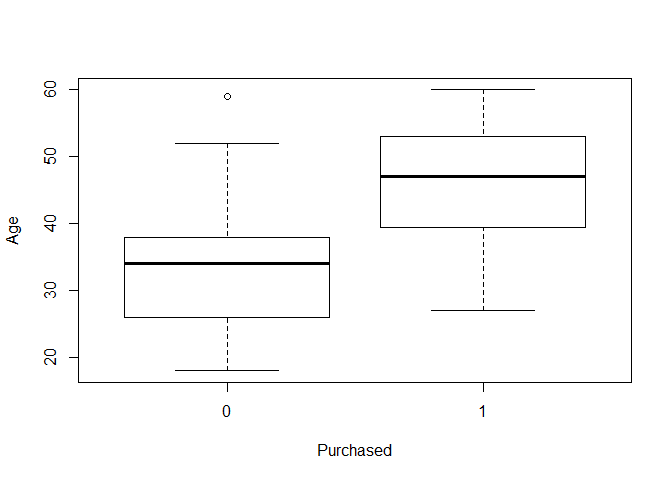

```r
boxplot(Age~Purchased,data = dataset)
```

A première vue, on constate bien une relation entre l’Age et l’achat ou non. En effet l’écart inter-groupe semble graphiquement supérieur à l’écart intra-groupe.

On va vérifier cette relation avec le test paramètrique ANOVA.

```r
test1=aov(Age~Purchased,data = dataset)
summary(test1)
```

```
##              Df Sum Sq Mean Sq F value Pr(>F)
## Purchased     1  16988   16988   251.7 <2e-16 ***
## Residuals   398  26858      67
## ---
## Signif. codes:  0 '***' 0.001 '**' 0.01 '*' 0.05 '.' 0.1 ' ' 1
```

Attention, ces résultats ne sont valides que si les données respectent les hypothèses du test :

- Normalité des résidus:

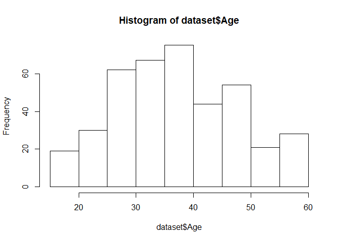

```r
hist(dataset$Age)
```

```r
shapiro.test(dataset$Age)
```

```
##
##  Shapiro-Wilk normality test
##
## data:  dataset$Age
## W = 0.9785, p-value = 1.164e-05
```

L’hypothèse de normalité n’est pas confirmée, ni visuellement, ni par le test. Cependant vu que l’échantillon est grand, on accepte l’hypothèse de normailté avec le TCL.

- Homogénéité de la variance:

```r
library(car)
dataset$Purchased=as.factor(dataset$Purchased)
leveneTest(dataset$Age,dataset$Purchased)
```

```
## Levene's Test for Homogeneity of Variance (center = median)
##        Df F value Pr(>F)
## group   1  0.2659 0.6064
##       398
```

La p-value est supérieur au seuil, on ne rejette pas l’hypothèse initiale et donc on accepte l’égalité des variances. On peut confirmer ce test visuellement avec le box Plot.

### On s’intérèsse à la relation entre le salaire et l’achat ou non

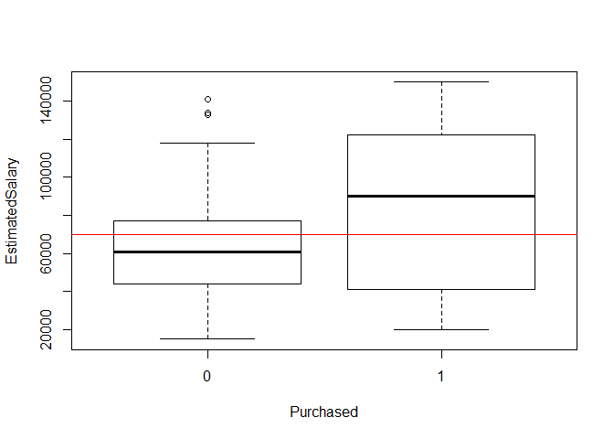

```r
boxplot(EstimatedSalary~Purchased,data=dataset)
abline(h=mean(dataset$EstimatedSalary),col='red')
```

Visuellement on a du mal à confirmer la précense ou non de relation entre nos variables. On peut juste observer la précence de quelques valeurs particulières.

Aparté outliers :

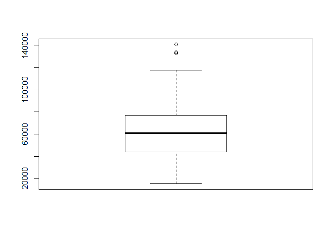

```r
NoPurchase=dataset[dataset$Purchased==0,]
boxplot(NoPurchase$EstimatedSalary)
```

```r
outliers=boxplot.stats(NoPurchase$EstimatedSalary)$out
outliers
```

```
## [1] 133000 141000 134000
```

```r
outliersIndex=which(NoPurchase$EstimatedSalary %in% c(outliers))
outliersIndex
```

```
## [1] 210 213 222
```

```r
NoPurchase[outliersIndex,]
```

```
##      User.ID Gender Age EstimatedSalary Purchased
## 271 15680752 Female  43          133000         0
## 285 15638646   Male  48          141000         0
## 307 15603942 Female  51          134000         0
```

On test la relation avec un test paramétrique ANOVA.

```r
test2=aov(EstimatedSalary~Purchased,data = dataset)
summary(test2)
```

```
##              Df    Sum Sq   Mean Sq F value   Pr(>F)
## Purchased     1 6.082e+10 6.082e+10   60.05 7.77e-14 ***
## Residuals   398 4.031e+11 1.013e+09
## ---
## Signif. codes:  0 '***' 0.001 '**' 0.01 '*' 0.05 '.' 0.1 ' ' 1
```

Vérifions les hypothèses de validités du test.

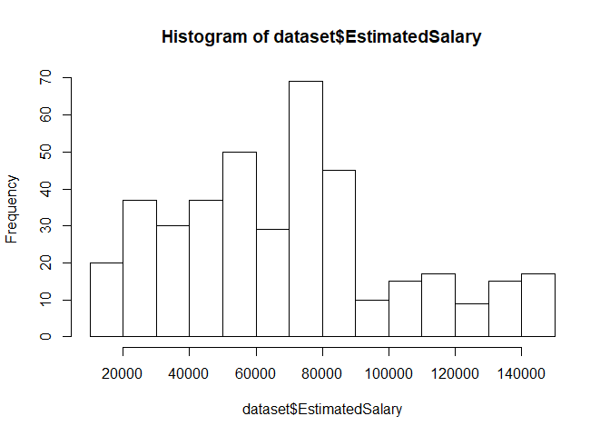

```r
hist(dataset$EstimatedSalary)
```

```r
shapiro.test(dataset$EstimatedSalary)
```

```
##
##  Shapiro-Wilk normality test
##
## data:  dataset$EstimatedSalary
## W = 0.96001, p-value = 5.735e-09
```

Même conclusion que précédemment.

```r
leveneTest(dataset$EstimatedSalary,dataset$Purchased)
```

```
## Levene's Test for Homogeneity of Variance (center = median)
##        Df F value    Pr(>F)
## group   1   86.49 < 2.2e-16 ***
##       398
## ---
## Signif. codes:  0 '***' 0.001 '**' 0.01 '*' 0.05 '.' 0.1 ' ' 1
```

```r
dataset$Purchased=as.numeric(dataset$Purchased)
```

La p-value est inférieur au seuil. On rejette donc l’hypothèse nulle et donc l’homogénéité des variances.

Dans ce cas on peut utiliser la correction de Welch. Cependant doit-on vraiment s’embêter à étudier toutes ces hypothèses?

### On s’intéresse à la relation entre le sexe et le l’achat ou non

On utilise d’abord un tableau croisé.

```r
table(dataset$Gender,dataset$Purchased)
```

```
##
##            1   2
##   Female 127  77
##   Male   130  66
```

On observe une proportion plutot égale d’homme et de femme ayant acheté le produit.

Représentons graphiquement notre relation.

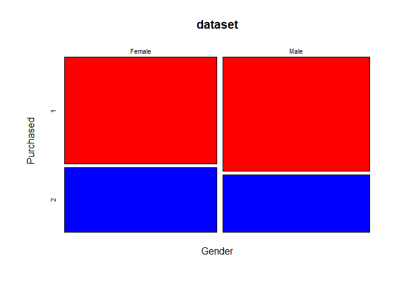

```r
mosaicplot(Gender~Purchased,data = dataset,col=c('red','blue'))
```

A première c’est difficile d’établir une relation entre ces variables. Réalisons un test statistique pour tester l’absence ou non de relation. On utilise un test de khi-deux.

```r
chisq.test(dataset$Gender,dataset$Purchased)
```

```
##
##  Pearson's Chi-squared test with Yates' continuity correction
##
## data:  dataset$Gender and dataset$Purchased
## X-squared = 0.55509, df = 1, p-value = 0.4562
```

## Analyse discriminante linéaire :

```r
library(caTools)
subset=dataset[,-c(1,2)]

set.seed(42)
sample=sample.split(dataset$Purchased,SplitRatio = 0.75)
train=subset[sample==TRUE,]
test=subset[sample==FALSE,]
```

### Observons nos données :

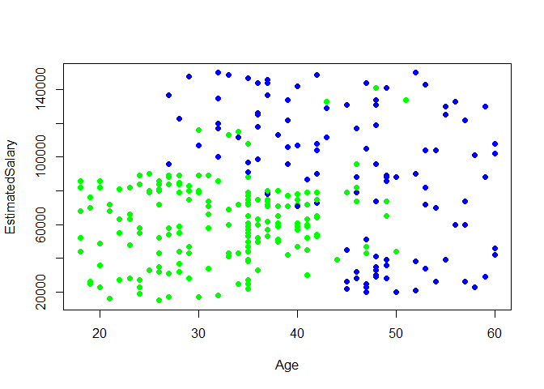

```r
colors=ifelse(train$Purchased==1,"green","blue")
plot(train[,c(1,2)],pch=16,col=colors)
```

Une normalisation peut-il aider à mieux visualiser les données?

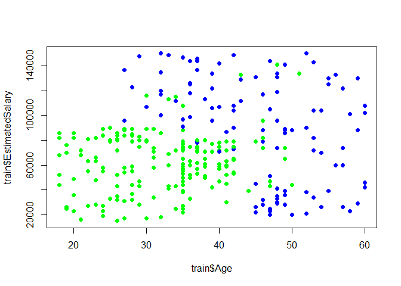

```r
trainScale=train
trainScale[,c(1,2)]=scale(trainScale[,c(1,2)])

testScale=test
testScale[,c(1,2)]=scale(testScale[,c(1,2)])
plot(train$Age,train$EstimatedSalary,pch=16,col=colors)
```

Sans surprise on observe pas de différence flagrante.

Une normalisation différente aurait-elle eu un impact différent?

### Réalisons le modèle :

Réalisons notre analyse discriminante sans normaliser nos données.

```r
library(MASS)
modele_lda=lda(Purchased~.,data = train)
summary(modele_lda)
```

```
##         Length Class  Mode
## prior   2      -none- numeric
## counts  2      -none- numeric
## means   4      -none- numeric
## scaling 2      -none- numeric
## lev     2      -none- character
## svd     1      -none- numeric
## N       1      -none- numeric
## call    3      -none- call
## terms   3      terms  call
## xlevels 0      -none- list
```

```r
modele_lda$prior
```

```
##         1         2
## 0.6433333 0.3566667
```

```r
modele_lda$means
```

```
##        Age EstimatedSalary
## 1 32.56477        62316.06
## 2 45.51402        88485.98
```

On observe les probabilités prior pour chaque groupe, probabilités déja connu auparavant mais rappelons les : 64% des individus n’achètent pas et 35% achètent.

On observe les moyennes de chaque groupe.

```r
table(dataset$Purchased)
```

```
##
##   1   2
## 257 143
```

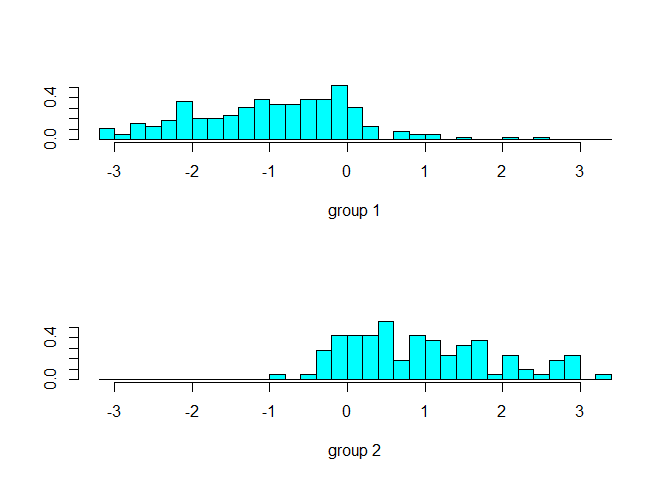

```r
plot(modele_lda)
```

On réalise nos prédictions.

```r
predictionsLDA1=predict(modele_lda,newdata = test)
table(predicted=predictionsLDA1$class,survived=test$Purchased)
```

```
##          survived
## predicted  1  2
##         1 58 11
##         2  6 25
```

Donc on remarque que notre modèle est faible. Il réalise 17 erreurs, soit un taux erreur de 17%.

Présentons graphiquement la différence entre les données prédictes et les données réelles.

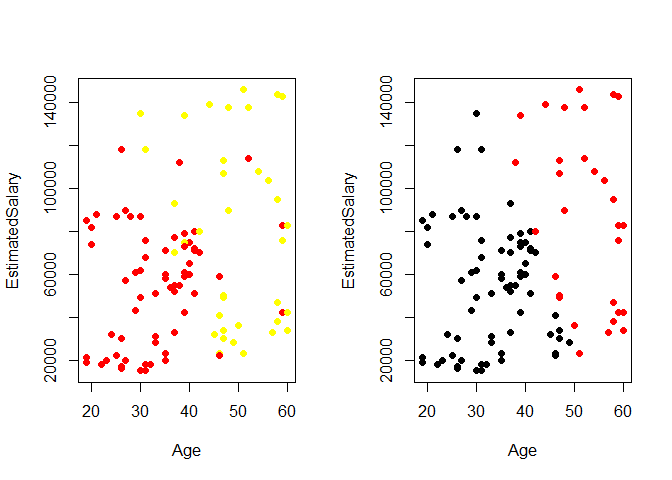

```r
par(mfrow=c(1,2))
colors1=ifelse(test$Purchased==1,'red','yellow')
plot(test[,c(1,2)],col=colors1,pch=16)
plot(test[,c(1,2)],col=predictionsLDA1$class,pch=16)
```

```r
#a1 = seq(min(train[,1]) - 1, max(train[, 1]) + 1, by = 0.01)
#a2 = seq(min(train[,2]) - 1, max(train[, 2]) + 1, by = 0.01)
#grid_set = expand.grid(a1, a2)
## Adapt the variable names
#colnames(grid_set) = c('Age', 'EstimatedSalary')

## plot 'Estimated Salary' ~ 'Age'
#plot(test[, 1:2],
     #main = 'Decision Boundary LDA',
     #xlab = 'Age', ylab = 'Estimated Salary',
     #xlim = range(a1), ylim = range(a2))

# color the plotted points with their real label (class)
#points(test[1:2], pch = 21, bg = ifelse(test[, 3] == 1, 'green4', 'red3'))

# Make predictions on the points of the grid, this will take some time
#pred_grid = predict(modeleLDA, newdata = grid_set)$class

# Separate the predictions by a contour
#contour(a1, a2, matrix(as.numeric(pred_grid), length(a1), length(a2)), add = TRUE)
```

Tracons la courbe ROC dans ce cas.

```r
library(ROCR)
score=prediction(predictionsLDA1$posterior[,2],test$Purchased)
AUC=performance(score,'auc')
AUC@y.values
```

```
## [[1]]
## [1] 0.9177517
```

L’aire sous la courbe est très bon. Notre modèle est finalement intéréssant.

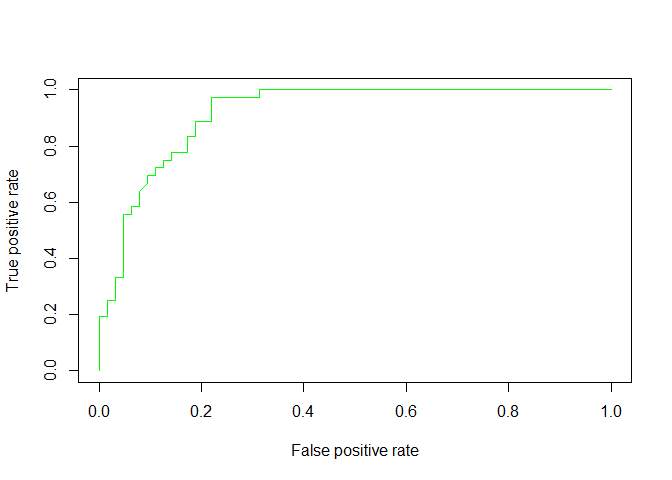

```r
plot(performance(score,"tpr","fpr"),col='green')
```

On utilisera cette courbe pour comparer avec le modèle quadratique.

### Analyse discriminante quadratique :

```r
modele_qda=qda(Purchased~.,data=trainScale)
summary(modele_qda)
```

```
##         Length Class  Mode
## prior   2      -none- numeric
## counts  2      -none- numeric
## means   4      -none- numeric
## scaling 8      -none- numeric
## ldet    2      -none- numeric
## lev     2      -none- character
## N       1      -none- numeric
## call    3      -none- call
## terms   3      terms  call
## xlevels 0      -none- list
```

```r
modele_qda$prior
```

```
##         1         2
## 0.6433333 0.3566667
```

```r
modele_qda$means
```

```
##          Age EstimatedSalary
## 1 -0.4547273      -0.2789171
## 2  0.8202090       0.5030935
```

On réalise nos prédictions.

```r
predictionsQDA=predict(modele_qda,newdata = testScale)
table(predicted=predictionsQDA$class,survived=testScale$Purchased)
```

```
##          survived
## predicted  1  2
##         1 59 11
##         2  5 25
```

Le modèle n’est psa bien meilleure que le précedent. On observe 16 erreurs, soit un taux de 16% d’erreur.

Visualisons ces erreurs:

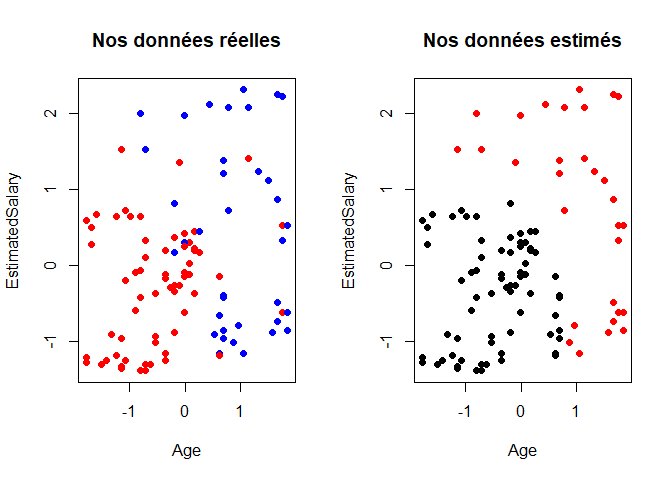

```r
par(mfrow=c(1,2))
couleur1=ifelse(test$Purchased==1,'red','blue')
plot(testScale[,c(1,2)],col=couleur1,pch=16,main='Nos données réelles')
plot(testScale[,c(1,2)],col=predictionsQDA$class,pch=16,main='Nos données estimés')
```

Le modèle ne saisit pas totalement la compléxité du modèle. Certaines valeurs à la limite des deux classes sont mal identifiés par le modèle.

Visualisons les frontières.

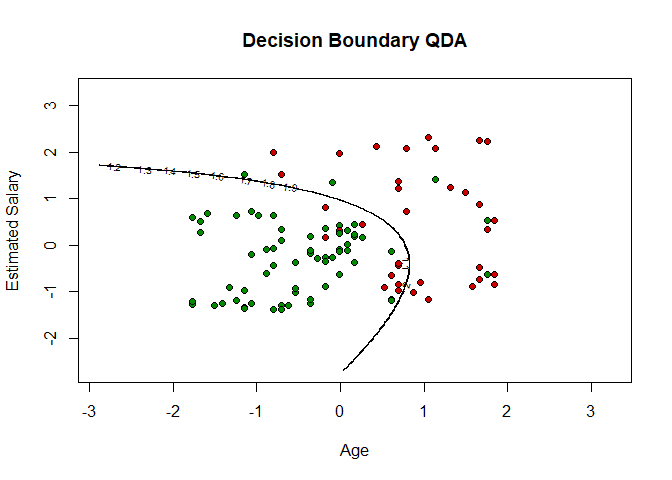

```r
a1 = seq(min(trainScale[, 1]) - 1, max(trainScale[, 1]) + 1, by = 0.01)
a2 = seq(min(trainScale[, 2]) - 1, max(trainScale[, 2]) + 1, by = 0.01)
grid_set = expand.grid(a1, a2)
# Adapt the variable names
colnames(grid_set) = c('Age', 'EstimatedSalary')

# plot 'Estimated Salary' ~ 'Age'
plot(testScale[, 1:2],
     main = 'Decision Boundary QDA',
     xlab = 'Age', ylab = 'Estimated Salary',
     xlim = range(a1), ylim = range(a2))

# color the plotted points with their real label (class)
points(testScale[1:2], pch = 21, bg = ifelse(testScale[, 3] == 1, 'green4', 'red3'))

# Make predictions on the points of the grid, this will take some time
pred_grid = predict(modele_qda, newdata = grid_set)$class

# Separate the predictions by a contour
contour(a1, a2, matrix(as.numeric(pred_grid), length(a1), length(a2)), add = TRUE)
```

Comparons nos deux modèles :

```r
score_QDA=prediction(predictionsQDA$posterior[,2],testScale$Purchased)
AUC_QDA=performance(score,'auc')
AUC_QDA@y.values
```

```
## [[1]]
## [1] 0.9177517
```

Affichons nos deux courbes pour les comparer.

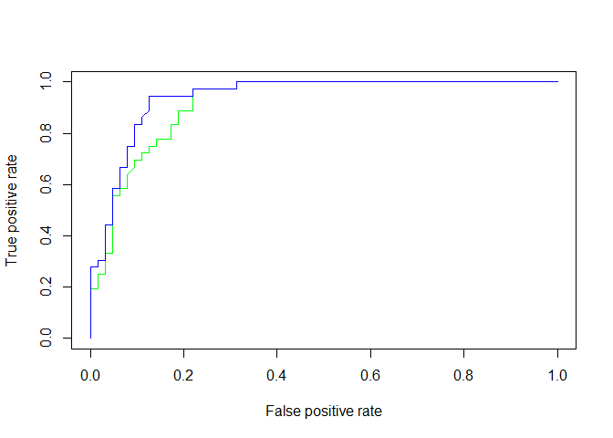

```r
plot(performance(score,"tpr","fpr"),col='green')
plot(performance(score_QDA,"tpr","fpr"),col='blue',add=TRUE)
```

On graphique que le second modèle est le meilleure.

### Analyse discriminante de bayes :

Dans ce cas, on suppose que les variables Age et Estimated Salary sont indépendantes. Voyons voir si cela est vrai.

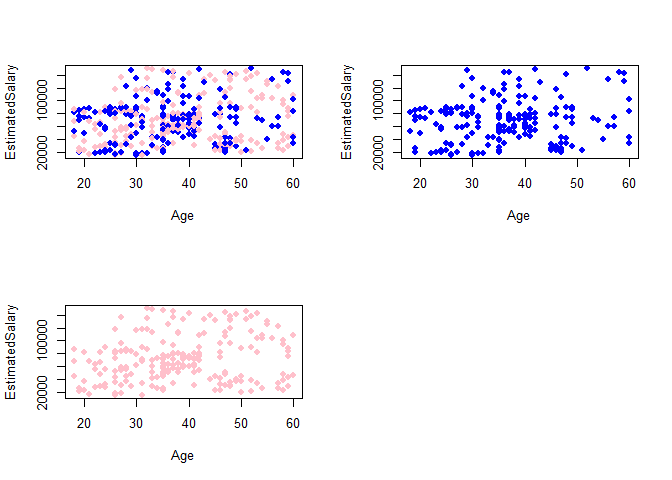

```r
par(mfrow=c(2,2))
colourT=ifelse(dataset$Gender=='Male','blue','pink')
plot(dataset[,c(3,4)],pch=16,col=colourT)
plot(dataset[dataset$Gender=="Male",c(3,4)],col='blue',pch=16)
plot(dataset[dataset$Gender=="Female",c(3,4)],col='pink',pch=16)
```

Visuellement deja il est difficile de déterminer si oui ou non nos variables sont dépendantes. Il semblerait qu’il y a une faible corrélation positive tout de même.

```r
cor(dataset[,c(3,4)])
```

```
##                      Age EstimatedSalary
## Age             1.000000        0.155238
## EstimatedSalary 0.155238        1.000000
```

Selon la matrice de corrélation, on a une corrélation positive faible entre les deux variables.

```r
cor.test(dataset$Age,dataset$EstimatedSalary,method=c("spearman"))
```

```
##
##  Spearman's rank correlation rho
##
## data:  dataset$Age and dataset$EstimatedSalary
## S = 9335149, p-value = 0.01247
## alternative hypothesis: true rho is not equal to 0
## sample estimates:
##       rho
## 0.1248243
```

On ne peut donc pas rejeter l’hypothèse H0 avec un seuil de 1%. Dans ce cas on accepte l’hypothèse que nos variables sont indépendantes.

Donc on va réaliser nos analyse de bayes. Attention on doit passer notre réponse en facteur.

```r
library(e1071)
trainScale$Purchased=as.factor(trainScale$Purchased)
modele_naive=naiveBayes(Purchased~.,data = trainScale)
summary(modele_naive)
```

```
##           Length Class  Mode
## apriori   2      table  numeric
## tables    2      -none- list
## levels    2      -none- character
## isnumeric 2      -none- logical
## call      4      -none- call
```

```r
modele_naive$apriori
```

```
## Y
##   1   2
## 193 107
```

```r
modele_naive$tables
```

```
## $Age
##    Age
## Y         [,1]      [,2]
##   1 -0.4547273 0.7602342
##   2  0.8202090 0.8475327
##
## $EstimatedSalary
##    EstimatedSalary
## Y         [,1]      [,2]
##   1 -0.2789171 0.6901964
##   2  0.5030935 1.2493030
```

Réalisons nos prédictions.

```r
predictionsN=predict(modele_naive,newdata = testScale)
predictionsN1=predict(modele_naive,newdata = testScale,type = 'raw')
head(predictionsN1)
```

```
##              1          2
## [1,] 0.9883683 0.01163174
## [2,] 0.9050868 0.09491317
## [3,] 0.9732178 0.02678224
## [4,] 0.9351226 0.06487736
## [5,] 0.5994625 0.40053752
## [6,] 0.6020862 0.39791379
```

```r
table(predicted=predictionsN,survived=testScale$Purchased)
```

```
##          survived
## predicted  1  2
##         1 60 11
##         2  4 25
```

Le modèle est meilleure avec un taux d’erreur de 15%.

Comparons avec les modèles précédents.

```r
scoreN=prediction(predictionsN1[,2],testScale$Purchased)
AUC_N=performance(scoreN,'auc')
AUC_N@y.values
```

```
## [[1]]
## [1] 0.9398872
```

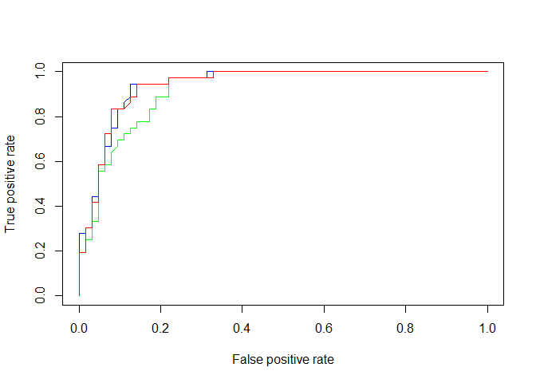

```r
plot(performance(score,"tpr","fpr"),col='green')
plot(performance(score_QDA,"tpr","fpr"),col='blue',add=TRUE)
plot(performance(scoreN,"tpr","fpr"),col='red',add=TRUE)
```

## Quelques informations supplémentaires :

### Ajoutons un prédicteur qualitative :

```r
trainQ=dataset[sample==TRUE,-1]
testQ=dataset[sample==FALSE,-1]
modele_lda_Q=lda(Purchased~.,data = trainQ)
summary(modele_lda_Q)
```

```
##         Length Class  Mode
## prior   2      -none- numeric
## counts  2      -none- numeric
## means   6      -none- numeric
## scaling 3      -none- numeric
## lev     2      -none- character
## svd     1      -none- numeric
## N       1      -none- numeric
## call    3      -none- call
## terms   3      terms  call
## xlevels 1      -none- list
```

```r
modele_lda_Q$prior
```

```
##         1         2
## 0.6433333 0.3566667
```

```r
modele_lda_Q$counts
```

```
##   1   2
## 193 107
```

```r
modele_lda_Q$lev
```

```
## [1] "1" "2"
```

```r
modele_lda_Q$svd
```

```
## [1] 16.03634
```

```r
modele_lda_Q$N
```

```
## [1] 300
```

```r
modele_lda_Q$call
```

```
## lda(formula = Purchased ~ ., data = trainQ)
```

```r
table(predicted=predict(modele_lda_Q,newdata = testQ)$class,survived=testQ$Purchased)
```

```
##          survived
## predicted  1  2
##         1 57 11
##         2  7 25
```

Les avis divergent sur l’utilisation ou non de predicteurs quantitaive.

### Des graphs sympas:

```r
library(caret)
library(AppliedPredictiveModeling)
```

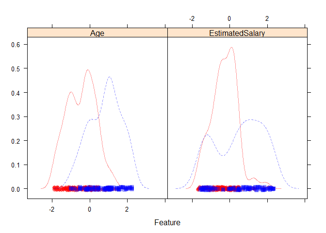

```r
transparentTheme(trans = .4)
featurePlot(x=trainScale[,1:2],y = as.factor(trainScale[,3]),plot='density')
```

Au vue du précédent graph, les courbes de densité sont plus ou moins bien séparés pour les deux variables. Surtout en ce qui concerne l’age, aurait-on de meilleure résultat sans la variable sur le salaire?

```r
lda_W=lda(Purchased~Age,data = trainScale)
predictionLDA=predict(lda_W,newdata=testScale)
table(predicted=predictionLDA$class,survived=testScale$Purchased)
```

```
##          survived
## predicted  1  2
##         1 59  8
##         2  5 28
```

Un taux d’erreur de 13%. Bien mieux?!?

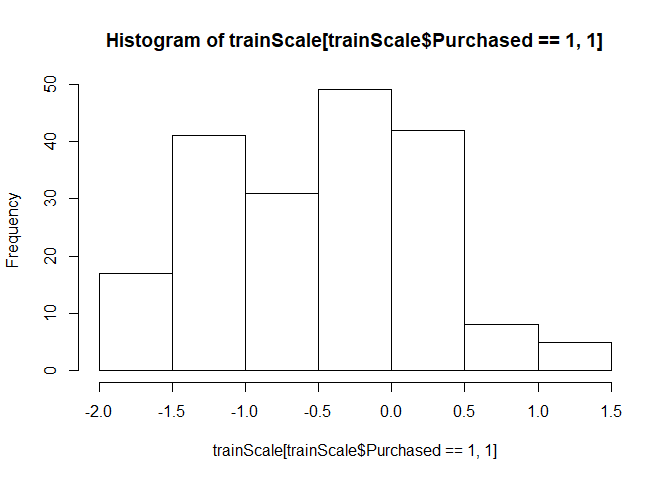

```r
hist(trainScale[trainScale$Purchased==1,1])
```

### Remarque final

```r
#library(klaR)
#selec1=greedy.wilks(wheat~.,data = train,niveau=0.01)
#selec1$results
#selec1$formula
```

Permet de réaliser une sélection des variables forward selon le critère lambda wilk. Le niveau correspond au seuil de précision ici 1%.